# final_code

# Step2: data cleaning

Remove all the redundant symbols. Count missing values and remove the missing rows. Seperate salaries into max and min and calculate the mean. Save the data set as “data.final.csv”. 1.

```r
data.glassdoor<- read.csv("../../data/glass_door.csv")
Companyname_m<-length(which(is.na(data.glassdoor$Company)))
#102 positions miss companies' name

#remove "-" of location
data.glassdoor$Location<-gsub("–", "", as.character(data.glassdoor$Location))
#remove leading space of location
data.glassdoor$Location<-str_trim(data.glassdoor$Location,"left")
location_m.1<-length(which(is.na(data.glassdoor$Location)))
location_m.2<-length(which(data.glassdoor$Location=="Remote"))
location_m.3<-length(which(data.glassdoor$Location=="United States"))
#21 position miss location including "remote"and "United States"

indus_m<-length(which(is.na(data.glassdoor$Industry)))
#79 position miss Industry
data.glassdoor$Industry=gsub("&amp", "", as.character(data.glassdoor$Industry))

rating_m<-length(which(is.na(data.glassdoor$Rating)))
##41 position miss rating

skill_m<-length(which(is.na(data.glassdoor[,7:19])))
##13 position miss rating

#create a column named max salary
 data.glassdoor$max=rep(NA,nrow(data.glassdoor))
  data.glassdoor$min=rep(NA,nrow(data.glassdoor))

  for (f in 1:nrow(data.glassdoor)){
   s=data.glassdoor$Salaries[f]
    if (is.na(s) ){
    data.glassdoor$max[f]=NA
    data.glassdoor$min[f]=NA
  }
  else
   max1=unlist(strsplit(as.character(s),'-'))[2]
   max2=unlist(strsplit(as.character(max1),'k'))[1]
 data.glassdoor$max[f]=rm1stchar(max2, n = 1)[1]

  min1=unlist(strsplit(as.character(s),'-'))[1]
  min2=unlist(strsplit(as.character(min1),'k'))[1]
 data.glassdoor$min[f]=rm1stchar(min2, n = 1)[1]
  }

salary_m<-length(which(is.na(data.glassdoor[,21:22])))
##78 position miss salary

 #remove missing values(industry,salary,rate,location)
data.final<-data.glassdoor[(complete.cases(data.glassdoor[3:22])),]
data.final$mean<-(as.numeric(data.final$max)+as.numeric(data.final$min))/2
data.final<-data.final[-which(data.final$Location=="Remote"|data.final$Location=="United States"),]
data.final<-data.final[,-1]
table(data.final$Industry)
```

```
##
##                 Accounting ; Legal                Aerospace ; Defense
##                                  8                                 13
##             Agriculture ; Forestry   Arts, Entertainment ; Recreation
##                                  5                                  6
##          Biotech ; Pharmaceuticals                  Business Services
##                                 16                                 91
## Construction, Repair ; Maintenance                  Consumer Services
##                                  1                                  3
##                          Education                            Finance
##                                 17                                 61
##                         Government                        Health Care
##                                  6                                 23
##             Information Technology                          Insurance
##                                241                                 27
##                      Manufacturing                              Media
##                                 34                                 27
##                    Mining ; Metals                         Non-Profit
##                                  1                                  2
##       Oil, Gas, Energy ; Utilities                        Real Estate
##                                  9                                  3
##  Restaurants, Bars ; Food Services                             Retail
##                                  1                                 23
##                 Telecommunications         Transportation ; Logistics
##                                  6                                 11
##                   Travel ; Tourism
##                                  4
```

```r
#Therefore, we have 639 positions totally
```

Save the data as data.final.csv

```r
write.csv(data.final,file = "data.final.csv")
```

# Step3:Exploratory analysis and Visualization

plot the top 10 skills for both data scientist and data engineer and two-proportion test 1.

```r
data.final<- read.csv("../../data/data.final.csv")
data.final<-data.final[,-1]
a=1
skill.whole<-rep(NA,13)
for(i in 6:18){
  skill.whole[a]<-length(which(data.final[,i]==TRUE))
a=a+1
  }
skills<-c("Python","R","SAS","SQL","Java","Tableau","Spark","C","Perl","Excel","Hadoop","NoSQL","HBase")
count.whole<-data.frame(as.numeric(unlist(skill.whole)))
count.whole$skills<-skills
colnames(count.whole)<-c("Count(DS","Skills")
count.whole$Count<-as.numeric(count.whole$Count)

#data engineer
skill_stat<-read.csv("../../data/glass_door_statana.csv")
skill_stat<-skill_stat[,-1]
b=1
skill_stat.1<-rep(NA,13)
for(i in 3:15){
  skill_stat.1[b]<-length(which(skill_stat[,i]==TRUE))
b=b+1
  }
count.whole$Count<-as.numeric(unlist(skill_stat.1))
count.whole<-count.whole[,c(2,1,3)]
colnames(count.whole)<-c("Skills","Count(DS)","Count(DE)")
count.whole$'Occurrence%(DS)'<-round((count.whole$`Count(DS)`)/nrow(data.final)*100,2)
count.whole$'Occurrence%(DE)'<-round((count.whole$`Count(DE)`)/nrow(skill_stat)*100,2)
count.whole<-arrange(count.whole,desc(`Count(DS)`))
```

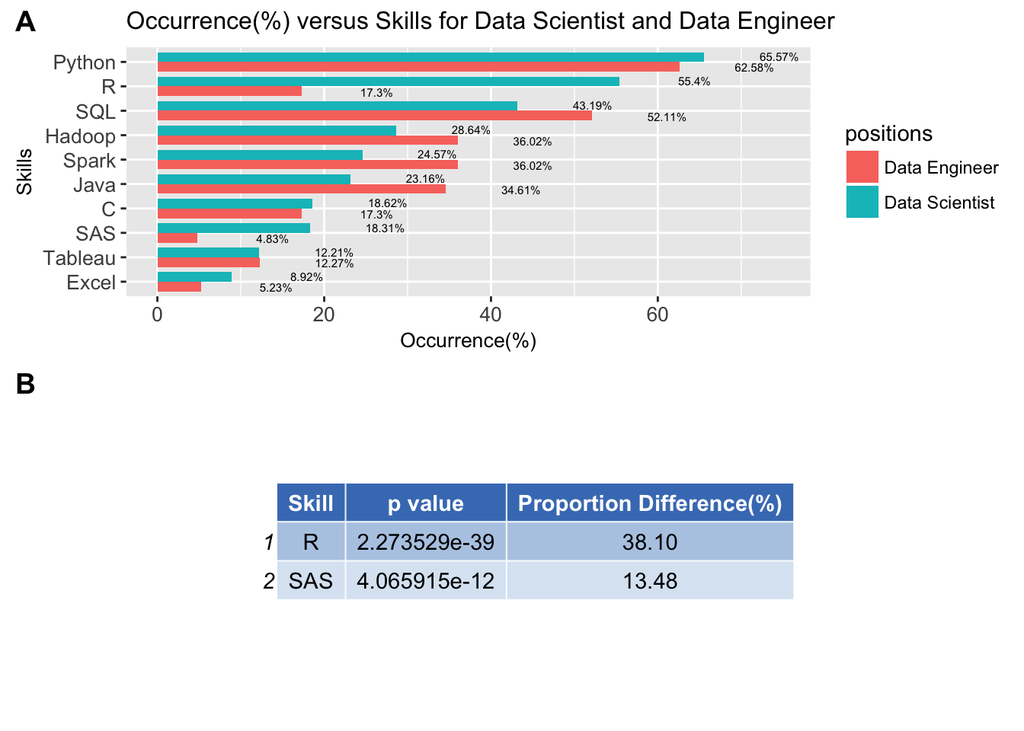

```r
count.whole.top10<-count.whole[1:10,]

count.whole.top10$Skills<-factor(count.whole.top10$Skills, levels = count.whole.top10$Skills[order(count.whole.top10$`Count(DS)`)])
count.whole.1<-melt(count.whole.top10[,c(1,4,5)],id.vars='Skills')
count.whole.1$positions<-c(rep("Data Scientist",10),rep("Data Engineer",10))


p_skills<-ggplot(data=count.whole.1,aes(Skills,value,fill=positions))+
  geom_bar(stat="identity",position="dodge",width = 0.8)+
  coord_flip() + labs(x = 'Skills', y = 'Occurrence(%)')+ggtitle('Occurrence(%) versus Skills for Data Scientist and Data Engineer')+theme(plot.title = element_text(size=12))+theme(axis.title.x = element_text(size =10))+theme(axis.text = element_text(siz=10 ))+theme(axis.title.y = element_text(size =10))+
    geom_text(aes(y = value + 9,    # nudge above top of bar
                  label = paste0(value, '%')),    # prettify
              position = position_dodge(width = .9),
              size = 2)


#statistical analysis of R and SAS

test.R<-prop.test(c(count.whole.top10[2,2],count.whole[2,3]),c(nrow(data.final),nrow(skill_stat)),correct=FALSE,alternative="greater")

test.SAS<-prop.test(c(count.whole.top10[8,2],count.whole[8,3]),c(nrow(data.final),nrow(skill_stat)),correct=FALSE,alternative="greater")


skills.2<-c("R","SAS")
p.value<-c(test.R$p.value,test.SAS$p.value)
hyp.test<-as.data.frame(skills.2)
hyp.test$p<-p.value
hyp.test$`proportion difference`<-c(count.whole.top10[2,4]-count.whole.top10[2,5],count.whole.top10[8,4]-count.whole.top10[8,5])
colnames(hyp.test)<-c("Skill","p value","Proportion Difference(%)")

table.skill<-ggtexttable(hyp.test,theme = ttheme("mBlue"))

p.skill.t<-ggarrange(p_skills,table.skill,nrow= 2,labels = c('A', 'B'))


ggsave("../../figure/count_skills.png",p.skill.t,width = 7, height = 5)
p.skill.t
```

Collect longitude and latitude of each location using function geocode. Data was saved as “data.location_1.csv”. Code is not evaluated. 2.

```r
data.location<-as.data.frame(data.final$Location[!is.na(data.final$Location)==TRUE])
colnames(data.location)<-"Location"
data.location$lon<-rep(NA,nrow(data.location))
data.location$lat<-rep(NA,nrow(data.location))

for(l in 1:nrow(data.location)){
  ll=as.character(data.location$Location[l])
b=any(grepl("\\,", ll, ignore.case=TRUE))
      if(length(b)=="FALSE")
{data.location$lon=NA
data.location$lat=NA
}

else
data.location$lon[l]=geocode(ll)[1]
data.location$lat[l]=geocode(ll)[2]
Sys.sleep(1)
}

data.location_1<-as.data.frame(unlist(data.location$Location))
data.location_1$lon<-unlist(data.location$lon)
data.location_1$lat<-unlist(data.location$lat)
colnames(data.location_1)<-c("City","lon","lat")

write.csv(data.location_1,file ="data.location_1.csv")
```

plot US map using get_map

```r
map<-get_map(location='united states', zoom=4, maptype = "terrain",             source='google',color='color')
```

[figure not shown]

```r
#Geographically visualized the distribution of data scientist positions
#make a table of top five cities that hire most data scientists
data.location_1= read.csv("../../data/data.location_1.csv")
data.location_1=data.location_1[,-1]
data.location_1<-data.location_1[(complete.cases(data.location_1)),]
data.location_2=add_count(data.location_1, City)
data.location_2<-subset(data.location_2, !duplicated(data.location_2))
colnames(data.location_2)<-c("City","lon","lat","Count")

gmap=ggmap(map) +geom_point(aes(x=lon, y=lat,size=Count), data=data.location_2,alpha=0.5,col="orange")+
  xlab("longitude") +
  ylab("latitude")+scale_size_continuous(range = c(0.5, 7))


data.position.count<-data.location_2
data.position.count.2<-arrange(data.position.count,desc(Count))
data.position.count.3<-subset(data.position.count.2, !duplicated(data.position.count.2[,"City"]))

industryrank<-data.frame(table(data.final$Industry))
industryrank.1<- industryrank[order(industryrank$Freq,decreasing=TRUE),][1:5,]
colnames(industryrank.1)=c("Industry","Count")
industryrank.1$Industry<-  factor(industryrank.1$Industry, levels = industryrank.1$Industry[order(industryrank.1$Count)])
industryrank.1$Frequency<-round(((industryrank.1$Count)/nrow(data.final))*100,3)


p1<-ggplot(data=industryrank.1,aes(factor(Industry),y=Count,fill=Count),width = 2, height = 3,alpha=.8)+geom_bar(stat="identity",width=0.8)+coord_flip()+labs(y="Count",x="Industry",size=3)+ggtitle("Count versus Industry in the US")+theme(plot.title = element_text(size=12))+theme(axis.title.x = element_text(size =10))+theme(axis.text = element_text(siz=10 ))+theme(axis.title.y = element_text(size=10))+scale_fill_gradient2()
rownames(industryrank.1) <- c()


ppp<-ggarrange(p1,gmap,nrow= 2,labels = c('A', 'B'))
ggsave("../../figure/indus.png",width = 7, height = 5)
ppp
```

Step4:Statistical analysis 1.

```
## Start:  AIC=3845.57
## mean ~ factor(ind) + factor(region) + Rating + R + Python + SQL +
##     Hadoop + Spark
##
##                  Df Sum of Sq    RSS    AIC
## - SQL             1       108 378887 3843.7
## - R               1       147 378927 3843.8
## - Hadoop          1       536 379316 3844.4
## - Rating          1       552 379332 3844.4
## <none>                        378780 3845.6
## - Spark           1      1700 380480 3846.2
## - Python          1      3705 382485 3849.3
## - factor(ind)     3      9738 388518 3854.6
## - factor(region)  3     59031 437811 3925.2
##
## Step:  AIC=3843.74
## mean ~ factor(ind) + factor(region) + Rating + R + Python + Hadoop +
##     Spark
##
##                  Df Sum of Sq    RSS    AIC
## - R               1       104 378991 3841.9
## - Hadoop          1       519 379406 3842.5
## - Rating          1       549 379436 3842.6
## <none>                        378887 3843.7
## - Spark           1      1666 380553 3844.3
## + SQL             1       108 378780 3845.6
## - Python          1      3615 382502 3847.3
## - factor(ind)     3      9908 388795 3853.0
## - factor(region)  3     59077 437965 3923.4
##
## Step:  AIC=3841.9
## mean ~ factor(ind) + factor(region) + Rating + Python + Hadoop +
##     Spark
##
##                  Df Sum of Sq    RSS    AIC
## - Rating          1       543 379534 3840.7
## - Hadoop          1       577 379568 3840.8
## <none>                        378991 3841.9
## - Spark           1      1706 380697 3842.6
## + R               1       104 378887 3843.7
```

[output cut: 17 more lines]

```
## - factor(region)  3     61591 441125 3923.6
##
## Step:  AIC=3839.42
## mean ~ factor(ind) + factor(region) + Python + Spark
##
##                  Df Sum of Sq    RSS    AIC
## <none>                        379969 3839.4
## + Hadoop          1       435 379534 3840.7
## + Rating          1       401 379568 3840.8
## + R               1       148 379821 3841.2
## + SQL             1        45 379924 3841.4
## - Spark           1      2783 382752 3841.7
## - Python          1      5855 385825 3846.5
## - factor(ind)     3      9869 389838 3848.6
## - factor(region)  3     61374 441344 3921.9
```

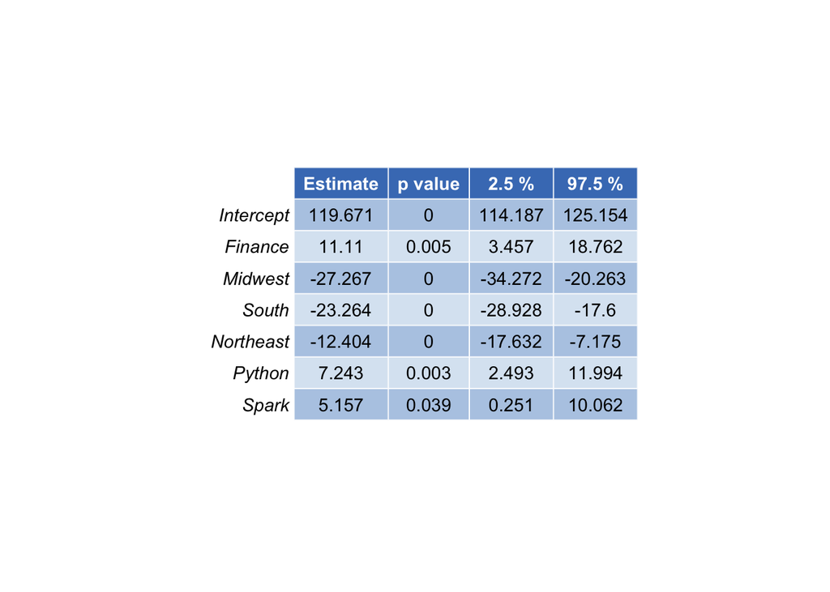

appendix 1.

```r
#CSS selector and XPath
Information<-c("field","linking url","salary","rating","company's name","location","skills")
CSS<-c(".jl","a.jobLink","small",".compactStars",".padRtSm",".subtle","#JobDescContainer")
html.node<-data.frame(Information)
html.node$html_node<-CSS
ht<-ggtexttable(html.node,theme = ttheme("mBlue"))
ggsave("../../figure/html_node.png",ht,width = 5, height = 3)
```

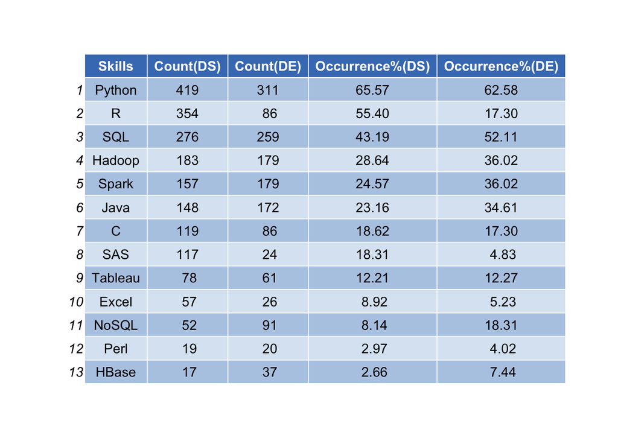

```r
#skills and count
ggtexttable(count.whole,theme = ttheme("mBlue"))
```

```r
ggsave("../../figure/count.whole.png",width = 7, height = 5)
```

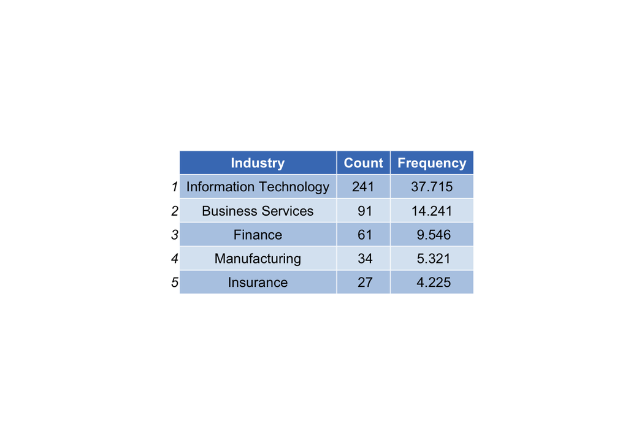

```r
#industry count
ggtexttable(industryrank.1,theme = ttheme("mBlue"))
```

```r
ggsave("../../figure/industryrank.1.png",width = 6, height = 5)
```

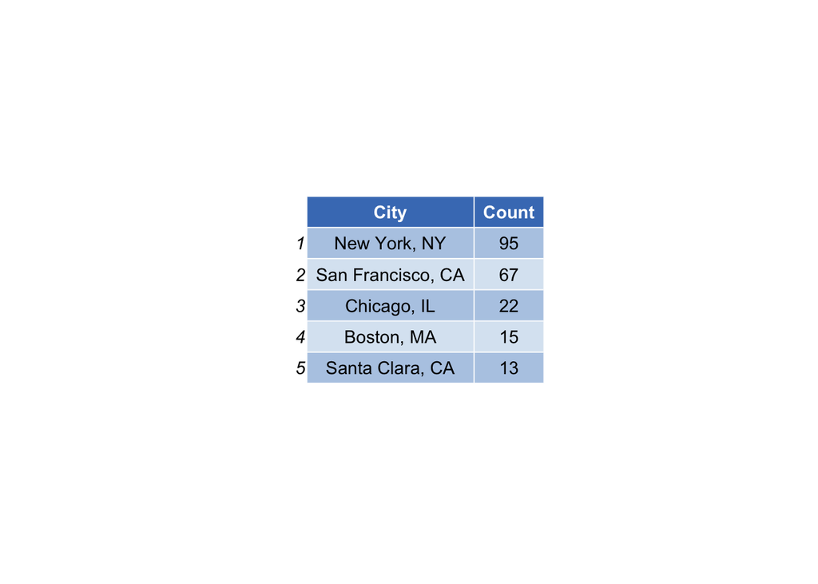

```r
#Top 5 cities that hire most data scientists
data.position.final<-ggtexttable(data.position.count.3[1:5,c(1,4)],theme = ttheme("mBlue"))
ggsave("../../figure/data.position.final.png",width = 5, height = 5)
data.position.final
```

```r
citation(package="rvest")
```

```
##
##
##   Hadley Wickham (2016). rvest: Easily Harvest (Scrape) Web Pages.
##   R package version 0.3.2.
##   https://CRAN.R-project.org/package=rvest
##
## A BibTeX entry for LaTeX users is
##
##   @Manual{,
##     title = {rvest: Easily Harvest (Scrape) Web Pages},
##     author = {Hadley Wickham},
##     year = {2016},
##     note = {R package version 0.3.2},
##     url = {https://CRAN.R-project.org/package=rvest},
##   }
```

```r
citation(package = "dplyr")
```

```
##
##
##   Hadley Wickham, Romain Francois, Lionel Henry and Kirill Müller
##   (2017). dplyr: A Grammar of Data Manipulation. R package version
##   0.7.4. https://CRAN.R-project.org/package=dplyr
##
## A BibTeX entry for LaTeX users is
##
##   @Manual{,
##     title = {dplyr: A Grammar of Data Manipulation},
##     author = {Hadley Wickham and Romain Francois and Lionel Henry and Kirill Müller},
##     year = {2017},
##     note = {R package version 0.7.4},
##     url = {https://CRAN.R-project.org/package=dplyr},
##   }
```

```r
citation(package = "httr")
```

```
##
##
##   Hadley Wickham (2017). httr: Tools for Working with URLs and
##   HTTP. R package version 1.3.1.
##   https://CRAN.R-project.org/package=httr
##
## A BibTeX entry for LaTeX users is
##
##   @Manual{,
##     title = {httr: Tools for Working with URLs and HTTP},
##     author = {Hadley Wickham},
##     year = {2017},
##     note = {R package version 1.3.1},
##     url = {https://CRAN.R-project.org/package=httr},
##   }
```

```r
citation(package = "stringr")
```

```
##
##
##   Hadley Wickham (2017). stringr: Simple, Consistent Wrappers for
##   Common String Operations. R package version 1.2.0.
##   https://CRAN.R-project.org/package=stringr
##
## A BibTeX entry for LaTeX users is
##
##   @Manual{,
##     title = {stringr: Simple, Consistent Wrappers for Common String Operations},
##     author = {Hadley Wickham},
##     year = {2017},
##     note = {R package version 1.2.0},
##     url = {https://CRAN.R-project.org/package=stringr},
##   }
```

```r
citation(package = "curl")
```

```
##
##
##   Jeroen Ooms (2017). curl: A Modern and Flexible Web Client for
##   R. R package version 2.8.1.
##   https://CRAN.R-project.org/package=curl
##
## A BibTeX entry for LaTeX users is
##
##   @Manual{,
##     title = {curl: A Modern and Flexible Web Client for R},
##     author = {Jeroen Ooms},
##     year = {2017},
##     note = {R package version 2.8.1},
##     url = {https://CRAN.R-project.org/package=curl},
##   }
```

```r
citation(package = "hydroTSM")
```

```
##
##
##   Mauricio Zambrano-Bigiarini. (2017) hydroTSM: Time Series
##   Management, Analysis and Interpolation for Hydrological
##   ModellingR package version 0.5-1. URL
##   https://github.com/hzambran/hydroTSM. DOI:10.5281/zenodo.839864.
##
## A BibTeX entry for LaTeX users is
##
##   @Manual{,
##     title = {hydroTSM: Time Series Management, Analysis and Interpolation for Hydrological Modelling},
##     author = {{Mauricio Zambrano-Bigiarini}},
##     year = {2017},
##     note = {R package version 0.5-1 . doi: https://doi.org/10.5281/zenodo.83964},
##     url = {https://github.com/hzambran/hydroTSM},
##   }
##
## I have invested a lot of time and effort in creating hydroTSM,
## please cite it if you use it !
```

```r
citation(package = "tidyr")
```

```
##
##
##   Hadley Wickham (2016). tidyr: Easily Tidy Data with `spread()`
##   and `gather()` Functions. R package version 0.6.0.
##   https://CRAN.R-project.org/package=tidyr
##
## A BibTeX entry for LaTeX users is
##
##   @Manual{,
##     title = {tidyr: Easily Tidy Data with `spread()` and `gather()` Functions},
##     author = {Hadley Wickham},
##     year = {2016},
##     note = {R package version 0.6.0},
##     url = {https://CRAN.R-project.org/package=tidyr},
##   }
```

```r
citation(package = "ggplot2")
```

```
##
##
##   H. Wickham. ggplot2: Elegant Graphics for Data Analysis.
##   Springer-Verlag New York, 2009.
##
## A BibTeX entry for LaTeX users is
##
##   @Book{,
##     author = {Hadley Wickham},
##     title = {ggplot2: Elegant Graphics for Data Analysis},
##     publisher = {Springer-Verlag New York},
##     year = {2009},
##     isbn = {978-0-387-98140-6},
##     url = {http://ggplot2.org},
##   }
```

```r
citation(package = "ggpubr")
```

```
##
##
##   Alboukadel Kassambara (2017). ggpubr: 'ggplot2' Based
##   Publication Ready Plots. R package version 0.1.5.
##   https://CRAN.R-project.org/package=ggpubr
##
## A BibTeX entry for LaTeX users is
##
##   @Manual{,
##     title = {ggpubr: 'ggplot2' Based Publication Ready Plots},
##     author = {Alboukadel Kassambara},
##     year = {2017},
##     note = {R package version 0.1.5},
##     url = {https://CRAN.R-project.org/package=ggpubr},
##   }
```

```r
citation(package = "gridExtra")
```

```
##
##
##   Baptiste Auguie (2017). gridExtra: Miscellaneous Functions for
##   "Grid" Graphics. R package version 2.3.
##   https://CRAN.R-project.org/package=gridExtra
##
## A BibTeX entry for LaTeX users is
##
##   @Manual{,
##     title = {gridExtra: Miscellaneous Functions for "Grid" Graphics},
##     author = {Baptiste Auguie},
##     year = {2017},
##     note = {R package version 2.3},
##     url = {https://CRAN.R-project.org/package=gridExtra},
##   }
```

```r
citation(package = "reshape2")
```

```
##
##
##   Hadley Wickham (2007). Reshaping Data with the reshape Package.
##   Journal of Statistical Software, 21(12), 1-20. URL
##   http://www.jstatsoft.org/v21/i12/.
##
## A BibTeX entry for LaTeX users is
##
##   @Article{,
##     title = {Reshaping Data with the {reshape} Package},
##     author = {Hadley Wickham},
##     journal = {Journal of Statistical Software},
##     year = {2007},
##     volume = {21},
##     number = {12},
##     pages = {1--20},
##     url = {http://www.jstatsoft.org/v21/i12/},
##   }
```

```r
citation(package = "MASS")
```

```
##
##
##   Venables, W. N. & Ripley, B. D. (2002) Modern Applied Statistics
##   with S. Fourth Edition. Springer, New York. ISBN 0-387-95457-0
##
## A BibTeX entry for LaTeX users is
##
##   @Book{,
##     title = {Modern Applied Statistics with S},
##     author = {W. N. Venables and B. D. Ripley},
##     publisher = {Springer},
##     edition = {Fourth},
##     address = {New York},
##     year = {2002},
##     note = {ISBN 0-387-95457-0},
##     url = {http://www.stats.ox.ac.uk/pub/MASS4},
##   }
```

```r
citation(package = "ggmap")
```

```
##
##
##   D. Kahle and H. Wickham. ggmap: Spatial Visualization with
##   ggplot2. The R Journal, 5(1), 144-161. URL
##   http://journal.r-project.org/archive/2013-1/kahle-wickham.pdf
##
## A BibTeX entry for LaTeX users is
##
##   @Article{,
##     author = {David Kahle and Hadley Wickham},
##     title = {ggmap: Spatial Visualization with ggplot2},
##     journal = {The R Journal},
##     year = {2013},
##     volume = {5},
##     number = {1},
##     pages = {144--161},
##     url = {http://journal.r-project.org/archive/2013-1/kahle-wickham.pdf},
##   }
```

```r
citation(package = "grid")
```

```
##
## The 'grid' package is part of R.  To cite R in publications use:
##
##   R Core Team (2016). R: A language and environment for
##   statistical computing. R Foundation for Statistical Computing,
##   Vienna, Austria. URL https://www.R-project.org/.
##
## A BibTeX entry for LaTeX users is
##
##   @Manual{,
##     title = {R: A Language and Environment for Statistical Computing},
##     author = {{R Core Team}},
##     organization = {R Foundation for Statistical Computing},
##     address = {Vienna, Austria},
##     year = {2016},
##     url = {https://www.R-project.org/},
##   }
##
## We have invested a lot of time and effort in creating R, please
## cite it when using it for data analysis. See also
## 'citation("pkgname")' for citing R packages.
```

```r
citation(package = "knitr")
```

```
##
##
##   Yihui Xie (2017). knitr: A General-Purpose Package for Dynamic
##   Report Generation in R. R package version 1.17.
##
##   Yihui Xie (2015) Dynamic Documents with R and knitr. 2nd
##   edition. Chapman and Hall/CRC. ISBN 978-1498716963
##
##   Yihui Xie (2014) knitr: A Comprehensive Tool for Reproducible
##   Research in R. In Victoria Stodden, Friedrich Leisch and Roger
##   D. Peng, editors, Implementing Reproducible Computational
##   Research. Chapman and Hall/CRC. ISBN 978-1466561595
```